# 🧬 Data Preparation and Genomic Annotation for AI-based Genetic Risk Prediction 🧬

Jafet Arauz

2025-03-24

## 1 - Introduction 🔍

Polygenic Risk Scores (PRS) are commonly used to predict genetic risk but are limited by their dependence on reference populations and their inability to specify affected regulatory pathways or tissues. To address these limitations, this project aims to develop tissue-specific genetic risk predictors using Gene Set Activity Scores (GSAS), which measure how gene expression of molecular processes is affected across various tissues, providing more specific and actionable risk predictions than traditional PRS.

The predicted expression from different variants will be integrated into GSAS using NetActivity. These GSAS will be correlated with breast cancer risk in public datasets and compared with established PRS to identify more precise genetic markers.

As a preliminary step, genomic data preparation, including variant annotation and imputation, is essential. This process involves preparing files for submission to the Michigan Imputation Server and utilizing tools such as PrediXcan, MetaXcan, and NetActivity to enhance predictive models. The ultimate goal is to generate actionable genetic markers that can improve genetic risk prediction for common diseases like breast cancer.

## 2 - Materials and Methods 🧩

Most of this work has been performed using the UNIX language from a Linux terminal, executed remotely by accessing a computing cluster via VPN Forticlient. Additionally, tools such as liftOver, PLINK, R, and Miniconda were used, along with the use of awk to filter lines by specific columns and convert .bim files to .bed, while grep is used to search for exact rsID matches present in lists or reference files through literal search (-w, -F, -f). The complete process is described below, from environment preparation to imputation on the Michigan server.

## 3 - Work Environment Preparation 🧰

First, create and clone the repository to the cluster, and create working directories.

```bash
git clone https://github.com/JafetArauz16/TFM_Jafet_Arauz.git
```

Then, create the folder structure to be used with the purpose of organizing the files in the working environment.

```bash
mkdir Figuras Raw_Data  Result  Scrip  Temporales
```

Then, move to our Raw data folder and copy our working file using a symlink to avoid making modifications to the original file.

```bash
cd Raw_Data

ln -s /mnt/resultados/ml4bm/resultados/RawData/dbGAP/BreastCancer/phs000147.v3.p1_CGEMS/phg000032.v1.CGEMS_BreastCancer.genotype-calls-matrixfmt.HumanHap550v1.c1.GRU.tar.gz /home/garauzaguir/TFM_Jafet_Arauz/Raw_Data/phg000032.v1.CGEMS_BreastCancer.genotype-calls-matrixfmt.HumanHap550v1.c1.GRU.tar.gz
```

```bash
## Descomprimir los archivos que me acaban de asignar usando el enlace directo
tar -xzvf phg000032.v1.CGEMS_BreastCancer.genotype-calls-matrixfmt.HumanHap550v1.c1.GRU.tar.gz
```

### 3.1 Installation and Environment Preparation

A working environment was set up using **Conda** for package and dependency management, ensuring the correct installation of critical tools such as PLINK and LiftOver. Additionally, **R** was used with specific libraries for genomic variant annotation.

```bash
# movernos a nuestra carpete de Programas

cd ..
cd Programs

# Instalar Miniconda3

wget https://repo.anaconda.com/miniconda/Miniconda3-latest-Linux-x86_64.sh

bash Miniconda3-latest-Linux-x86_64.sh

conda --version
conda 24.11.1 # salida esperada

# Agregar los canales

conda config --add channels bioconda
conda config --add channels conda-forge
conda config --add channels defaults

# Crear un enviromnet donde instalare los programas para mi análisis

conda create -n GenoNexus_Env  python=3.9 # Esta version de python es la mas compatible con la mayoría de los programas
```

Activate the environment and install the first programs to be used.

```bash
# Instalar Plink
conda install -c bioconda -c conda-forge -c defaults plink  # usar esos dos canales       para una correcta instalación, Plink esta en Bioconda

# verificar instalcion
plink --version


#Instalar liftOver
conda install -c bioconda ucsc-liftover

# verificar instalcion
liftOver

# Instalar R con los paquetes escenciales
conda install -c conda-forge -c bioconda r-base r-essentials

# Revisar instalación
 R --version

# Abrir R e instalar Bioconductor
R                # abrir R siempre asegurarse que este activado el enviroment

# código para correr en R
install.packages("BiocManager")
install.packages("data.table")
install.packages("dplyr")

# Luego de intalar todo salir de R
q()
```

## 4 - Quality Control of Files with PLINK

PLINK was used for quality control and conversion of genomic files. [Purcell et al., 2007](https://www.cog-genomics.org/plink/).

```bash
# Realizar QC de los archivos
# Ir a la carpeta Scrip donde se guardaran los scrip generados
cd ..
cd Scrips

# Luego Crear el archivo bash con nano para gurardar los cambios
# CRTL + O , luego dar click en ENTER y luego para salir del editor CTRL + X

 nano QC_TFM_plink.sh
```

Demonstration of Bash scripts for quality control with PLINK.

PLINK is a free, open-source whole-genome association analysis toolset designed to efficiently perform various large-scale analyses of genotype and phenotype data. Its main focus is on statistical analysis rather than preliminary steps such as study design, raw data processing, or generating genotype or CNV calls. While PLINK is primarily intended for analysis, integration with tools like gPLINK and Haploview provides support for visualization, annotation, and storage of results. The software was developed by Shaun Purcell at the Center for Human Genetic Research (CHGR), Massachusetts General Hospital (MGH), and the Broad Institute of Harvard & MIT, with contributions from others.

For more information about PLINK, refer to its official website: [PLINK: Whole-genome association analysis toolset](https://www.cog-genomics.org/plink/).

First QC script

```bash
#!/bin/bash

# Definir direcrorios

QC_DIR="/home/garauzaguir/TFM_Jafet_Arauz/Results/QC_Results"
LOGS_DIR="${QC_DIR}/Logs/QC_Run_${DATE}"
ERRORS_DIR="${QC_DIR}/Errors/QC_Run_${DATE}"
OUTPUT_DIR="${QC_DIR}/Output/QC_Run_${DATE}"

# Definir directorio de entrada de datos

INPUT_DIR="/home/garauzaguir/TFM_Jafet_Arauz/Raw_Data/Matrix"

# Crear subcarpetas para esta ejecución

mkdir -p $LOGS_DIR $ERRORS_DIR $OUTPUT_DIR

# Registrar el inicio del Scrip

echo " Inicio del QC con PLINK en $(date)" >> $LOGS_DIR/qc_success_${DATE}.log

# Activar Conda y cargar el environment correcto
module load Anaconda3/2022.10
source /home/garauzaguir/TFM_Jafet_Arauz/Programas/Miniconda3/bin/activate GenoNexus_Env

# Acceder a la carpeta de trabajo
cd $INPUT_DIR || { echo "Error: No se pudo acceder a $INPUT_DIR" >> $ERRORS_DIR/plink_qc_${DATE}.err; exit 1; }

# Verificar si Plink está instalado
if ! command -v plink &> /dev/null
then
    echo " Error: Plink no está instalado en el entorno Conda.\nInstálalo con: conda install -c bioconda plink" >> $ERRORS_DIR/plink_qc_${DATE}.err
    exit 1
else
    echo " Plink está instalado y listo para usarse." >> $LOGS_DIR/plink_qc_${DATE}.log
fi

# Contar muestras sin sexo y documentarlas
awk '$5 == 0' nhs_subjects.fam > $OUTPUT_DIR/missing_sex_samples.txt
MISSING_SEX_COUNT=$(wc -l < $OUTPUT_DIR/missing_sex_samples.txt)
TOTAL_SAMPLES=$(wc -l < nhs_subjects.fam)

echo "Número de muestras sin sexo asignado: $MISSING_SEX_COUNT de $TOTAL_SAMPLES" | tee -a $OUTPUT_DIR/plink_qc.log

# Registrar información en un archivo
if [[ "$MISSING_SEX_COUNT" -gt 0 ]]; then
    echo "Las siguientes muestras no tienen sexo asignado:" >> $OUTPUT_DIR/plink_qc.log
    cat $OUTPUT_DIR/missing_sex_samples.txt >> $OUTPUT_DIR/plink_qc.log
fi

# Convertir archivos TPED/TFAM a formato binario BED/BIM/FAM
plink --tfile Cgem --make-bed --out $OUTPUT_DIR/Cgem_bin

# Aplicar control de calidad eliminando SNPs e individuos con muchos datos faltantes
plink --bfile nhs_subjects \
      --geno 0.10 \
      --mind 0.10 \
      --allow-no-sex \
      --make-bed \
      --out $OUTPUT_DIR/nhs_subjects_qc

# Desactivar Conda al final
conda deactivate

# **Si el script llegó hasta aquí sin fallos, mover logs y errores a la subcarpeta**
if ls $QC_DIR/Logs/plink_qc_*.log 1> /dev/null 2>&1; then
        mv $QC_DIR/Logs/plink_qc_*.log "$LOGS_DIR/"
fi

# Registrar finalización del script
echo " QC completado con éxito el $(date) ." >> $LOGS_DIR/qc_success_${DATE}.log
```

```bash
 # luego dar permiso de ejecución
 chmod +x QC_TFM_plink.sh
```

```bash
Now, to launch tasks on SLURM in the cluster, a script must be created to execute our script, where resources are assigned. Below is an example of the structure of a SLURM script.

# Ejemplo de scrip de slurm para gurardar los cambios
# CRTL + O , luego dar click en ENTER y luego para salir del editor CTRL + X

nano QC_TFM_plink.sl

# Escrbir esto en el editor nano
#!/bin/bash
#SBATCH -J PYTHON
#SBATCH --time=00:15:00
#SBATCH --ntasks=1
#SBATCH --mem-per-cpu=4G
#SBATCH -C skl
#SBATCH -p short

QC_TFM_plink.sh

 # luego dar permiso de ejecución
 chmod +x QC_TFM_plink.sl

# Luego correr análisis subiéndolo con SLURM

sbatch QC_TFM_plink.sl
```

At this point, the first QC was not very efficient, and it was also noted that the original file did not have the reference genome annotations. Therefore, as the next step, the NCBI database was downloaded with two reference datasets to determine the annotations of the SNPs being worked with.

```bash
Navigate to the main folder, create a folder called Reference_data, and within this folder, create two subfolders to store the datasets for SNP classification.

cd ..
mkdir Reference_Data
cd Reference_Data
mkdir hg19  hg38
cd hg19
wget -O snp151_hg19.txt.gz http://hgdownload.cse.ucsc.edu/goldenPath/hg19/database/snp151.txt.gz

#Descomprimir archivo .gz descargado
gunzip snp151_hg19.txt.gz

# Cambiar de directorio para descargar el otro archivo de referencia
cd ..
cd hg38
wget -O snp151_hg38.txt.gz http://hgdownload.cse.ucsc.edu/goldenPath/hg38/database/snp151.txt.gz

#Descomprimir archivo .gz descargado
gunzip snp151_hg38.txt.gz
```

Now, go to the folder where the working file is located and extract only the IDs from each one to compare them with the downloaded datasets

```bash
# Navegar entre directorios hasta la carpeta donde esta el archivo original
cd ../..
cd Raw_Data
cd Matrix

# Extraer los ID y guaradarlos en un txt
cut -f2 -d' ' /home/garauzaguir/TFM_Jafet_Arauz/Raw_Data/Matrix/nhs_subjects.bim > /home/garauzaguir/TFM_Jafet_Arauz/Raw_Data/Matrix/rsids_list.txt
```

Now, go to the Scripts folder and create the script for comparison with the datasets

```bash
# Navegar al directorio principal y luego a la carpeta de Scrips
cd ../..
cd Scrip

# crear el scrip para hacer la comparacion entre los set de datos de referencia
# y el archivo que contiene los ID para gurardar los cambios
# CRTL + O , luego dar click en ENTER y luego para salir del editor CTRL + X

nano comparacion_SNPs.sh

# escribir esto en el scrip

# Obtener la fecha y hora actual en formato YYYY-MM-DD_HH-MM-SS
TIMESTAMP=$(date +%Y-%m-%d_%H-%M-%S)

# Definir rutas
RSIDS_FILE="/home/garauzaguir/TFM_Jafet_Arauz/Raw_Data/Matrix/rsids_list.txt"
HG19_FILE="/home/garauzaguir/TFM_Jafet_Arauz/Reference_Data/hg19/snp151_hg19_rsID.txt"
HG38_FILE="/home/garauzaguir/TFM_Jafet_Arauz/Reference_Data/hg38/snp151_hg38_rsID.txt"

# Definir carpetas de salida organizadas por fecha y hora
BASE_DIR="/home/garauzaguir/TFM_Jafet_Arauz/Results/CompareGenome_Results"
LOGS_DIR="$BASE_DIR/Logs/$TIMESTAMP"
ERRORS_DIR="$BASE_DIR/Errors/$TIMESTAMP"
OUTPUT_DIR="$BASE_DIR/Output/$TIMESTAMP"

# Crear carpetas si no existen
mkdir -p "$LOGS_DIR" "$ERRORS_DIR" "$OUTPUT_DIR"

# Definir nombres de archivos de salida dentro de las carpetas con fecha y hora
OUTPUT_HG19="$OUTPUT_DIR/snps_found_hg19.txt"
OUTPUT_HG38="$OUTPUT_DIR/snps_found_hg38.txt"
LOG_HG19="$LOGS_DIR/count_snps_hg19.log"
LOG_HG38="$LOGS_DIR/count_snps_hg38.log"

# Registrar inicio en el log
echo "Inicio de la comparación: $(date)" | tee -a "$LOGS_DIR/compare_genome.log"

# Verificar que los archivos de entrada existen
if [[ ! -f "$RSIDS_FILE" ]]; then
    echo "Error: Archivo RSID no encontrado: $RSIDS_FILE" | tee -a "$LOGS_DIR/compare_genome.log"
    exit 101
fi
if [[ ! -f "$HG19_FILE" ]]; then
    echo "Error: Archivo de referencia hg19 no encontrado: $HG19_FILE" | tee -a "$LOGS_DIR/compare_genome.log"
    exit 102
fi
if [[ ! -f "$HG38_FILE" ]]; then
    echo "Error: Archivo de referencia hg38 no encontrado: $HG38_FILE" | tee -a "$LOGS_DIR/compare_genome.log"
    exit 103
fi

# Comparación con hg19 (ARCHIVO COMPLETO ES LISTA DE RSID)
echo "Procesando hg19..." | tee -a "$LOGS_DIR/compare_genome.log"
if grep -wFf "$RSIDS_FILE" "$HG19_FILE" > "$OUTPUT_HG19"; then
    echo "Comparación con hg19 completada correctamente." | tee -a "$LOGS_DIR/compare_genome.log"
else
    echo "Error en la comparación con hg19." | tee -a "$LOGS_DIR/compare_genome.log"
    exit 201
fi

# Contar SNPs encontrados en hg19 y guardarlos en el log
SNP_COUNT_HG19=$(wc -l < "$OUTPUT_HG19")
echo "Número de SNPs encontrados en hg19: $SNP_COUNT_HG19" | tee -a "$LOGS_DIR/compare_genome.log"
echo "$SNP_COUNT_HG19" > "$LOG_HG19"

# Comparación con hg38 (ARCHIVO COMPLETO ES LISTA DE RSID)
echo "Procesando hg38..." | tee -a "$LOGS_DIR/compare_genome.log"
if grep -wFf "$RSIDS_FILE" "$HG38_FILE" > "$OUTPUT_HG38"; then
    echo "Comparación con hg38 completada correctamente." | tee -a "$LOGS_DIR/compare_genome.log"
else
    echo "Error en la comparación con hg38." | tee -a "$LOGS_DIR/compare_genome.log"
    exit 202
fi

# Contar SNPs encontrados en hg38 y guardarlos en el log
SNP_COUNT_HG38=$(wc -l < "$OUTPUT_HG38")
echo "Número de SNPs encontrados en hg38: $SNP_COUNT_HG38" | tee -a "$LOGS_DIR/compare_genome.log"
echo "$SNP_COUNT_HG38" > "$LOG_HG38"

# Registrar fin en el log
echo "Comparación completada: $(date)" | tee -a "$LOGS_DIR/compare_genome.log"


# luego dar permiso de ejecución
chmod +x comparacion_SNPs.sh

Now, to launch tasks on SLURM in the cluster, a script must be created to execute our script, where resources are assigned. Below is an example of the structure of a SLURM script.

# Ejemplo de scrip de slurm para gurardar los cambios
# CRTL + O , luego dar click en ENTER y luego para salir del editor CTRL + X

nano comparacion_SNPs.sl

# Escrbir esto en el editor nano
#!/bin/bash
#SBATCH -J PYTHON
#SBATCH --time=00:15:00
#SBATCH --ntasks=1
#SBATCH --mem-per-cpu=4G
#SBATCH -C skl
#SBATCH -p short

QC_TFM_plink.sh

 # luego dar permiso de ejecución
 chmod +x comparacion_SNPs.sl

# Luego correr análisis subiéndolo con SLURM

sbatch comparacion_SNPs.sl
```

Now, go to the folder where the output files were saved and analyze the results.

```bash
cd ..
cd Results/CompareGenome_Results/Output/2025-02-10_15-42-21

# Para saber que resultados se obtuvieron hacer los siguiente
comm -23 <(sort snps_found_hg19.txt | uniq) <(sort snps_found_hg38.txt | uniq) > only_in_hg19.txt
comm -13 <(sort snps_found_hg19.txt | uniq) <(sort snps_found_hg38.txt | uniq) > only_in_hg38.txt
comm -12 <(sort snps_found_hg19.txt | uniq) <(sort snps_found_hg38.txt | uniq) > shared_rsID.txt

# contar lineas para saber la cantidad de id de cada tipo de anotacion
wc -l only_in_hg19.txt
25 only_in_hg19.txt

wc -l only_in_hg38.txt
64 only_in_hg38.txt

wc -l shared_rsID.txt
541020 shared_rsID.txt
```

### 4.1 Obtained Results

With this information, there is now an idea of how the annotation of my data is distributed. Therefore, the next step is to proceed with the manual annotation of the data and convert the annotation from hg38 to hg37 (hg19) for future procedures.

## 5 - Manual Annotation with Bioconductor

The annotation of genomic variants was performed using AnnotationHub from Bioconductor. [Bioconductor](https://bioconductor.org/packages/release/bioc/html/AnnotationHub.html).

```bash
# Canbiar de directoria a la carpeta de scrip
cd ../../../..
cd Scrip

# Crear scrip de R con nano para realizar la anotacion con R y bioconductor para gurardar los cambios  CRTL + O , luego dar click en ENTER y luego para salir del editor CTRL + X

nano Anotacion_genoma.R

# Escribir en el editor de nano
# Cargar las librerias a utilizar

library(GenomicRanges)
library(AnnotationHub)
library(VariantAnnotation)
library(BiocManager)
library(data.table)
library(biomaRt)

cat("=== Iniciando proceso de anotación con Bioconductor ===\n")

# Cargar rutas desde las variables de entorno
ruta_data <- Sys.getenv("ARCHIVOS_DATA")
ruta_salidas <- Sys.getenv("SALIDAS")

# Cargar los datos

cat("Cargando archivo de datos principal...\n")

data <- fread(file.path(ruta_data, "nhs_subjects.bim"), header = FALSE, stringsAsFactors = FALSE)
colnames(data) <- c("Chromosome", "rsID", "GeneticDist", "Position", "Allele1", "Allele2")
cat("Archivo principal cargado exitosamente. Total de rsID en archivo principal:", nrow(data), "\n")

data$rsID <- as.character(data$rsID)

# Conectar a Ensembl para hg38
cat("Conectando a Ensembl para hg38...\n")
ensembl_hg38 <- useEnsembl(biomart = "ENSEMBL_MART_SNP", dataset = "hsapiens_snp")

# Obtener la anotación en hg38
cat("Anotando con hg38...")
hg38_annotations <- getBM(
  attributes = c("refsnp_id", "chr_name", "chrom_start", "allele", "minor_allele"),
  filters = "snp_filter",
  values = data$rsID,
  mart = ensembl_hg38
)

# Renombrar columnas
colnames(hg38_annotations) <- c("rsID", "Chromosome_annot", "Position_hg38", "Allele_Ref", "Allele_Minor")
hg38_annotations$rsID <- as.character(hg38_annotations$rsID)

# Identificar ensamblajes estándar y alternativos
standard_chromosomes <- as.character(c(1:22, "X", "Y", "MT"))
hg38_annotations$Is_Standard <- hg38_annotations$Chromosome_annot %in% standard_chromosomes

hg38_annotations <- hg38_annotations[order(-hg38_annotations$Is_Standard), ]
anyDuplicated(hg38_annotations$rsID)
cat("Número de duplicados en hg38 antes de eliminar: ", anyDuplicated(hg38_annotations$rsID), "\n")

# Eliminar duplicados en hg38_annotations
hg38_annotations <- hg38_annotations[!duplicated(hg38_annotations$rsID), ]
anyDuplicated(hg38_annotations$rsID)
cat("Número de duplicados en hg38 después de eliminar: ", anyDuplicated(hg38_annotations$rsID), "\n")

# anotaciones que no son estandar
non_standard_annotations <- hg38_annotations[!hg38_annotations$Is_Standard, ]
cat("Número de anotaciones no estándar:", nrow(non_standard_annotations), "\n")
non_standard_rsID <- non_standard_annotations$rsID

# Unir con los datos originales (asegurar orden original)
cat("Uniendo anotaciones con datos originales...\n")
annotated_data <- merge(data, hg38_annotations, by = "rsID", all.x = TRUE, sort = FALSE)

# Reemplazar Chromosome con Chromosome_annot donde existe una anotación
annotated_data[, Chromosome := ifelse(!is.na(Chromosome_annot), Chromosome_annot, Chromosome)]
annotated_data[, Position := ifelse(!is.na(Position_hg38), Position_hg38, Position)]

# Eliminar columnas innecesarias y forzar que solo queden las relevantes
annotated_data <- annotated_data[, .(rsID, Chromosome, GeneticDist, Position, Allele1, Allele2)]

# Identificar los rsID que no fueron anotados con hg38
rsID_sin_anotar <- annotated_data[Chromosome == 0, rsID]
rsID_sin_anotar <- as.character(rsID_sin_anotar)
cat("Número de rsID no encontrados en hg38:", length(rsID_sin_anotar), "\n")

##### Anotación con hg19 #####
sin_anotar <- data[rsID %in% rsID_sin_anotar]

cat("Anotando rsID faltantes con hg19...\n")
cat("Conectando a Ensembl para hg19...\n")
ensembl_hg19 <- useMart(biomart = "ENSEMBL_MART_SNP", dataset = "hsapiens_snp", host = "https://grch37.ensembl.org")

cat("Anotando rsID faltantes con hg19...\n")
hg19_annotations <- getBM(
  attributes = c("refsnp_id", "chr_name", "chrom_start", "allele", "minor_allele"),
  filters = "snp_filter",
  values = sin_anotar$rsID,
  mart = ensembl_hg19
)

colnames(hg19_annotations) <- c("rsID", "Chromosome_annot", "Position_hg37", "Allele_Ref", "Allele_Minor")
hg19_annotations$rsID <- as.character(hg19_annotations$rsID)

# Unir con los datos originales (asegurar orden original)
cat("Uniendo anotaciones con hg19...\n")
hg19_annotated <- merge(sin_anotar, hg19_annotations, by = "rsID", all.x = TRUE, sort = FALSE)

# Reemplazar Chromosome con Chromosome_annot donde existe una anotación
hg19_annotated[, Chromosome := ifelse(!is.na(Chromosome_annot), Chromosome_annot, Chromosome)]
hg19_annotated[, Position := ifelse(!is.na(Position_hg37), Position_hg37, Position)]

# Eliminar columnas innecesarias y forzar que solo queden las relevantes
hg19_annotated <- hg19_annotated[, .(rsID, Chromosome, GeneticDist, Position, Allele1, Allele2)]

# Identificar los rsID que no se encontraron ni en hg38 ni en hg19
not_found_rsID <- hg19_annotated[Chromosome == 0, rsID]
cat("Número de rsID no encontrados en ninguna referencia:", length(not_found_rsID), "\n")

# filtra la tabla de hg19 anotated solo con los que tienen anotacion
hg19_annotated <- hg19_annotated[!rsID %in% not_found_rsID]

# combinar hg19_annotated con annotated_data y guaradarlo como anotado_final
cat("Combinando todas las anotaciones...\n")
anotado_final <- rbind(annotated_data, hg19_annotated, fill = TRUE)
anyDuplicated(anotado_final$rsID)

# Eliminar duplicados en anotado_final
cat("Número de duplicados en el archivo final antes de eliminar:", anyDuplicated(anotado_final$rsID), "\n")
anotado_final <- anotado_final[!duplicated(anotado_final$rsID), ]
anyDuplicated(anotado_final$rsID)
cat("Número de duplicados en el archivo final después de eliminar:", anyDuplicated(anotado_final$rsID), "\n")

# Guardar el archivo anotado final
cat("Guardando archivo final anotado...\n")
fwrite(anotado_final, file.path(ruta_salidas, "nhs_subjects_anotado.bim"), sep = " ", col.names = FALSE)
cat("Archivo anotado guardado exitosamente.\n")

# Guardar rsID no encontrados
cat("Guardando archivo de rsID no encontrados...\n")
writeLines(not_found_rsID, file.path(ruta_salidas, "rsID_no_encontrados.txt"))
cat("Archivo de rsID no encontrados guardado exitosamente.\n")

cat("=== Proceso completado ===\n")

# luego dar permiso de ejecución
chmod +x Anotacion_genoma.R

Now, to launch tasks on SLURM in the cluster, a script must be created to execute our script, where resources are assigned. Below is an example of the structure of a SLURM script.

# Ejemplo de scrip de slurm para gurardar los cambios
# CRTL + O , luego dar click en ENTER y luego para salir del editor CTRL + X

nano  Anotacion_manual_bioconductor.sl

# Escrbir esto en el editor nano
#!/bin/bash
#SBATCH -J PYTHON
#SBATCH --time=00:15:00
#SBATCH --ntasks=1
#SBATCH --mem-per-cpu=4G
#SBATCH -C skl
#SBATCH -p short

# Crear la carpeta de resultados si no existe
mkdir -p /home/garauzaguir/TFM_Jafet_Arauz/Results/Anotacion_genoma_bioconductor
mkdir -p /home/garauzaguir/TFM_Jafet_Arauz/Results/Anotacion_genoma_bioconductor/Logs
mkdir -p /home/garauzaguir/TFM_Jafet_Arauz/Results/Anotacion_genoma_bioconductor/Outputs

# Definir las rutas como variables de entorno
export ARCHIVOS_DATA="/home/garauzaguir/TFM_Jafet_Arauz/Raw_Data/Matrix/"
export REFERENCIAS="/home/garauzaguir/TFM_Jafet_Arauz/Reference_Data/"
export SALIDAS="/home/garauzaguir/TFM_Jafet_Arauz/Results/Anotacion_genoma_bioconductor/Outputs"

# Cargar modulos y enviroment
source /home/garauzaguir/TFM_Jafet_Arauz/Programas/Miniconda3/etc/profile.d/conda.sh
conda activate GenoNexus_Env

# Ejecutar el script de R
Rscript Anotacion_genoma.R

# luego dar permiso de ejecución
chmod +x  Anotacion_manual_bioconductor.sl

# Luego correr análisis subiéndolo con SLURM

sbatch  Anotacion_manual_bioconductor.sl
```

View the obtained results.

```bash
# Cambiar de directorio
cd ..
cd Results/Anotacion_genoma_bioconductor/Logs

# Revisar las salidas log del scrip el cual contiene los informacion sobre el analisis

cat cat annotation_bioconductor_output_76233.txt

=== Iniciando proceso de anotación con Bioconductor ===
Cargando archivo de datos principal...
Archivo principal cargado exitosamente. Total de rsID en archivo principal: 546646

Conectando a Ensembl para hg38...
Anotando con hg38...[1] 541041
Número de duplicados en hg38 antes de eliminar:  541041
[1] 0
Número de duplicados en hg38 después de eliminar:  0
Número de anotaciones no estándar: 8
Uniendo anotaciones con datos originales...
Número de rsID no encontrados en hg38: 5584
Anotando rsID faltantes con hg19...
Conectando a Ensembl para hg19...
Anotando rsID faltantes con hg19...
Uniendo anotaciones con hg19...
Número de rsID no encontrados en ninguna referencia: 5582
Combinando todas las anotaciones...
[1] 546647
Número de duplicados en el archivo final antes de eliminar: 546647
[1] 0
Número de duplicados en el archivo final después de eliminar: 0
Guardando archivo final anotado...
Archivo anotado guardado exitosamente.
Guardando archivo de rsID no encontrados...
Archivo de rsID no encontrados guardado exitosamente.
=== Proceso completado ===
```

Since this annotation was performed using the Bioconductor database (AnnotationHub), I will proceed with manual annotation using the previously downloaded reference datasets, but also using R

```bash
# Cambiar de directorio a la carpeta de Scrip para crear el scrip de R
# para realizar la anoatacion manual con los ser de datos de referencia
# descargados

cd ../../..
cd Scrip

# crear scrip de R con nano para gurardar los cambios
# CRTL + O , luego dar click en ENTER y luego para salir del editor CTRL + X

nano Anotacion_genoma_con_R.R

# Escribir lo siguiente en el editor

# Cargar librerias
library(data.table)
library(dplyr)

cat("=== Iniciando proceso de anotación manual ===\n")

# Leer rutas desde variables de entorno definidas en el archivo .slurm
ruta_data <- Sys.getenv("ARCHIVOS_DATA")
ruta_referencias <- Sys.getenv("REFERENCIAS")
ruta_salidas <- Sys.getenv("SALIDAS")

# Comprobar si las rutas se cargaron correctamente
cat("Ruta de archivos de datos: ", ruta_data, "\n")
cat("Ruta de archivos de referencia: ", ruta_referencias, "\n")

# Cargar archivos
cat("Cargando archivo de datos principal...\n")

data <- fread(file.path(ruta_data, "nhs_subjects.bim"), header = FALSE, stringsAsFactors = FALSE)
colnames(data) <- c("Chromosome", "rsID", "Genetic_Distance", "Position", "Allele_Ref", "Allele_Minor")
cat("Archivo principal cargado exitosamente. Total de rsID en archivo principal:", nrow(data), "\n")

cat("Cargando archivos de referencia (hg19 y hg38)...\n")
hg19_reference <- fread(file.path(ruta_referencias, "hg19/snp151_hg19.txt"),
                        header = FALSE, stringsAsFactors = FALSE, select = c(5, 2, 3))

hg38_reference <- fread(file.path(ruta_referencias, "hg38/snp151_hg38.txt"),
                        header = FALSE, stringsAsFactors = FALSE, select = c(5, 2, 3))

cat("Archivos de referencia cargados exitosamente.\n")

# Renombrar las columnas para que coincidan con la estructura de 'data'
colnames(hg19_reference) <- c("rsID", "Chromosome", "Position")
colnames(hg38_reference) <- c("rsID", "Chromosome", "Position")

# Asegurar que los Chromosome no tengan el prefijo 'chr' (eliminar si existe)
hg19_reference$Chromosome <- gsub("chr", "", hg19_reference$Chromosome)
hg38_reference$Chromosome <- gsub("chr", "", hg38_reference$Chromosome)

# Asegurar que los rsID sean tipo carácter
hg19_reference$rsID <- as.character(hg19_reference$rsID)
hg38_reference$rsID <- as.character(hg38_reference$rsID)

# === Generar los subsets independientes ===
cat("Buscando coincidencias con hg38...\n")
# Encontrar coincidencias con hg38
hg38_subset <- merge(data, hg38_reference, by = "rsID")

hg38_subset <- hg38_subset %>%
  select(rsID, Chromosome_Ref = Chromosome.y, Position_Ref = Position.y)

# Definir los cromosomas estándar
standard_chromosomes <- as.character(c(1:22, "X", "Y", "MT"))
# Añadir columna para identificar si el cromosoma es estándar
hg38_subset$Is_Standard <- hg38_subset$Chromosome_Ref %in% standard_chromosomes
# Ordenar para dar prioridad a los estándar (TRUE = 1, FALSE = 0)
hg38_subset <- hg38_subset[order(-hg38_subset$Is_Standard), ]
cat("Número de duplicados encontrados en hg38 antes de eliminar:", anyDuplicated(hg38_subset$rsID), "\n")

# Eliminar duplicados priorizando los estándar
hg38_subset <- hg38_subset[!duplicated(hg38_subset$rsID), ]

# Confirmar que ya no hay duplicados
cat("Número de duplicados encontrados en hg38 después de eliminar:", anyDuplicated(hg38_subset$rsID), "\n")

# Identificar anotaciones que no son estándar
non_standard_annotations <- hg38_subset[!hg38_subset$Is_Standard, ]
non_standard_rsID <- non_standard_annotations$rsID
cat("Número de anotaciones no estándar en hg38:", nrow(non_standard_annotations), "\n")

cat("Coincidencias encontradas con hg38:", nrow(hg38_subset), "\n")

# Crear un vector con los rsID que NO se encontraron en hg38
rsID_no_encontrados_hg38 <- data %>%
  filter(!rsID %in% hg38_subset$rsID) %>%
  pull(rsID)

cat ("No fueron encontrados en hg38:", length(rsID_no_encontrados_hg38), "\n")

#### ahora con hg37 #####
# Filtrar 'data' solo para los rsID que no fueron encontrados en hg38
data_filtrada <- data %>% filter(rsID %in% rsID_no_encontrados_hg38)

# Encontrar coincidencias con hg19
cat("Buscando coincidencias con hg19...\n")
hg19_subset <- merge(data_filtrada, hg19_reference, by = "rsID")

hg19_subset <- hg19_subset %>%
  select(rsID, Chromosome_Ref = Chromosome.y, Position_Ref = Position.y)

cat("Coincidencias encontradas con hg19:", nrow(hg19_subset), "\n")

# Combinar ambos subsets en un solo data frame
subset_final <- bind_rows(hg38_subset, hg19_subset)

cat("Total de coincidencias encontradas (hg38 + hg19):", nrow(subset_final), "\n")

# === Actualizar el archivo 'data' basado en el subset_final ===

# Hacer un merge para traer la anotación encontrada
cat("Número de duplicados en subset_final antes de merge final:", anyDuplicated(subset_final$rsID), "\n")

data_annotated <- merge(data, subset_final, by = "rsID", all.x = TRUE)

# Actualizar la posición y cromosoma si en 'data' estaban en cero
data_annotated <- data_annotated %>%
  mutate(
    Chromosome = ifelse(Chromosome == 0 & !is.na(Chromosome_Ref), Chromosome_Ref, Chromosome),
    Position = ifelse(Position == 0 & !is.na(Position_Ref), Position_Ref, Position)
  ) %>%
  select(Chromosome, rsID, Genetic_Distance, Position, Allele_Ref, Allele_Minor)

cat("Proceso de actualización completado. Total de filas en archivo final:", nrow(data_annotated), "\n")

# Buscar los rsID que no se encontraron en ninguna base de referencia

rsID_no_encontrados <- data_annotated %>%
  filter(Chromosome == 0 & Position == 0) %>%
  pull(rsID)

cat("Número de rsID no encontrados en ninguna referencia:", length(rsID_no_encontrados), "\n")

# Guardar los rsID no encontrados en un archivo para analizarlos después
writeLines(rsID_no_encontrados, file.path(ruta_salidas, "rsID_no_encontrados.txt"))
cat("Lista de rsID no encontrados guardada exitosamente como 'rsID_no_encontrados.txt'.\n")

# Obtener el nombre del archivo original sin la extensión
archivo_original <- tools::file_path_sans_ext("nhs_subjects.bim")

# Crear el nombre del archivo anotado
nombre_archivo_anotado <- paste0(archivo_original, "_anotada.bim")

# Guardar el archivo anotado
fwrite(data_annotated, file.path(ruta_salidas, nombre_archivo_anotado), sep = " ", col.names = FALSE)

cat("Archivos de salida guardados exitosamente en: ", ruta_salidas, "\n")

# luego dar permiso de ejecución
chmod +x Anotacion_genoma_con_R.R

Now, to launch tasks on SLURM in the cluster, a script must be created to execute our script, where resources are assigned. Below is an example of the structure of a SLURM script

# Ejemplo de scrip de slurm para gurardar los cambios
# CRTL + O , luego dar click en ENTER y luego para salir del editor CTRL + X

nano  Anotacion_manual.sl

# Escrbir esto en el editor nano
#!/bin/bash
#SBATCH -J PYTHON
#SBATCH --time=00:15:00
#SBATCH --ntasks=1
#SBATCH --mem-per-cpu=4G
#SBATCH -C skl
#SBATCH -p short

# Crear la carpeta de resultados si no existe
mkdir -p /home/garauzaguir/TFM_Jafet_Arauz/Results/Anotacion_genoma
mkdir -p /home/garauzaguir/TFM_Jafet_Arauz/Results/Anotacion_genoma/Logs
mkdir -p /home/garauzaguir/TFM_Jafet_Arauz/Results/Anotacion_genoma/Outputs

# Definir las rutas como variables de entorno
export ARCHIVOS_DATA="/home/garauzaguir/TFM_Jafet_Arauz/Raw_Data/Matrix/"
export REFERENCIAS="/home/garauzaguir/TFM_Jafet_Arauz/Reference_Data/"
export SALIDAS="/home/garauzaguir/TFM_Jafet_Arauz/Results/Anotacion_genoma/Outputs"

# Cargar modulos y enviroment
conda activate GenoNexus_Env

# Ejecutar el script de R
Rscript Anotacion_genoma_con_R.R

# luego dar permiso de ejecución
chmod +x  Anotacion_manual.sl

# Luego correr análisis subiéndolo con SLURM

sbatch  Anotacion_manual.sl
```

View the obtained results

```bash
# Cambiar de directorio
cd ..
cd Results/Anotacion_genoma/Logs

# Revisar las salidas log del scrip el cual contiene los informacion sobre el analisis

cat annotation_output_76230.txt

=== Iniciando proceso de anotación manual ===
Ruta de archivos de datos:  /home/garauzaguir/TFM_Jafet_Arauz/Raw_Data/Matrix/
Ruta de archivos de referencia:  /home/garauzaguir/TFM_Jafet_Arauz/Reference_Data/
Cargando archivo de datos principal...
Archivo principal cargado exitosamente. Total de rsID en archivo principal: 546646
Cargando archivos de referencia (hg19 y hg38)...
Archivos de referencia cargados exitosamente.
Buscando coincidencias con hg38...
Número de duplicados encontrados en hg38 antes de eliminar: 189075
Número de duplicados encontrados en hg38 después de eliminar: 0
Número de anotaciones no estándar en hg38: 7
Coincidencias encontradas con hg38: 541084
No fueron encontrados en hg38: 5562
Buscando coincidencias con hg19...
Coincidencias encontradas con hg19: 25
Total de coincidencias encontradas (hg38 + hg19): 541109
Número de duplicados en subset_final antes de merge final: 0
Proceso de actualización completado. Total de filas en archivo final: 546646
Número de rsID no encontrados en ninguna referencia: 5537
Lista de rsID no encontrados guardada exitosamente como 'rsID_no_encontrados.txt'.
Archivos de salida guardados exitosamente en:  /home/garauzaguir/TFM_Jafet_Arauz/Results/Anotacion_genoma/Outputs
```

### 5.1 Now, Convert the Results to hg37 and Remove Unannotated Entries

LiftOver was used to convert the reference files from hg38 to hg19. [UCSC Genome Browser](http://genome.ucsc.edu/cgi-bin/hgLiftOver).

```bash
# Cambiar de directorio
cd ..
cd Outputs

# Convertir archivo rsID_no_encontrados.txt a formato limpio (sin caracteres invisibles o especiales)
tr -d '\r' < rsID_no_encontrados.txt | sort | uniq > rsID_no_encontrados_limpio.txt

# Buscar coincidencias exactas utilizando grep -w para evitar coincidencias parciales
grep -w -F -f rsID_no_encontrados_limpio.txt nhs_subjects_sin_Mito.bim > coincidencias_restantes_exactas.txt

# Filtrar las líneas que no están en rsID_no_encontrados_limpio.txt usando grep -w
grep -v -w -F -f rsID_no_encontrados_limpio.txt nhs_subjects_sin_Mito.bim > nhs_subjects_filtrada_final.bim

# comprobar resultados
 wc -l nhs_subjects_filtrada_final.bim # debe dar 541109

 # Convertir .bim a .bed (formato compatible con liftOver)
awk '{print $1, $4 - 1, $4, $2}' nhs_subjects_filtrada_final.bim > nhs_subjects_hg38.bed
```

```bash
# Cambiar de directorio
cd ../../..
cd Results
mkdir liftOver
cd liftOver

# Descargar hg38ToHg19.over.chain
wget http://hgdownload.cse.ucsc.edu/goldenpath/hg38/liftOver/hg38ToHg19.over.chain.gz

# Descomprimir
gunzip hg38ToHg19.over.chain.gz
```

Now, create the LiftOver script to perform the conversion

```bash
#Cambiar de directorio
cd ../..
cd Scrip

# Crear scrip de bash con nano para gurardar los cambios
# CRTL + O , luego dar click en ENTER y luego para salir del editor CTRL + X

nano liftOver.sh

# Escribir en el editor
#!/bin/bash

# =======================
# Script: liftOver.sh
# =======================
# Descripción: Convierte un archivo .bed de hg38 a hg19 utilizando liftOver.
# =======================

# Activar Conda y cargar el environment correcto
source /home/garauzaguir/TFM_Jafet_Arauz/Programas/Miniconda3/etc/profile.d/conda.sh
conda activate GenoNexus_Env

# =======================
# Definir rutas y archivos
# =======================
INPUT_DIR="/home/garauzaguir/TFM_Jafet_Arauz/Results/Anotacion_genoma/Outputs"
LIFTOVER_CHAIN="/home/garauzaguir/TFM_Jafet_Arauz/Results/liftOver/hg38ToHg19.over.chain"
OUTPUT_DIR="/home/garauzaguir/TFM_Jafet_Arauz/Results/liftOver/Output"
DATE=$(date +"%Y-%m-%d_%H-%M-%S")
UNMAPPED_FILE="${OUTPUT_DIR}/unmapped_snps_${DATE}.txt"
OUTPUT_BED="${OUTPUT_DIR}/nhs_subjects_hg19_${DATE}.bed"

# =======================
# Crear carpeta de salida si no existe
# =======================
mkdir -p "$OUTPUT_DIR"

# =======================
# Ejecutar LiftOver
# =======================
liftOver "${INPUT_DIR}/nhs_subjects_hg38_chr.bed" "$LIFTOVER_CHAIN" "$OUTPUT_BED" "$UNMAPPED_FILE"

# Desactivar environment
conda deactivate

# luego dar permiso de ejecución
chmod +x liftOver.sh

Now, to launch tasks on SLURM in the cluster, a script must be created to execute our script, where resources are assigned. Below is an example of the structure of a SLURM script

# Ejemplo de scrip de slurm para gurardar los cambios
# CRTL + O , luego dar click en ENTER y luego para salir del editor CTRL + X

nano QC_TFM_plink.sl

# Escrbir esto en el editor nano
#!/bin/bash
#SBATCH -J PYTHON
#SBATCH --time=00:15:00
#SBATCH --ntasks=1
#SBATCH --mem-per-cpu=4G
#SBATCH -C skl
#SBATCH -p short

# Ejecutar el script liftOver.sh
bash /home/garauzaguir/TFM_Jafet_Arauz/Scrip/liftOver.sh

# luego dar permiso de ejecución
chmod +x liftover_conversion.sl

# Luego correr análisis subiéndolo con SLURM
sbatch liftover_conversion.sl
```

Subsequently, the generated file must undergo QC and be prepared to be uploaded to the Michigan server for imputation, which requires the input file to be in .vcf format. Therefore, the PLINK tool will be used again to accomplish this

### 5.2 Conversion to VCF format and applying QC to the re-annotated file in hg37.

```bash
# Crear el scrip de bahs para la converison a .vcf y realizar QC para gurardar los cambios  CRTL + O , luego dar click en ENTER y luego para salir del editor CTRL + X

nano QC_convert_plink.sh

# Escribir en el editor
#!/bin/bash

# ============================
# Script: QC_convert_plink.sh
# Descripción: Convierte un archivo .bed a .vcf y realiza Control de Calidad con plink.
# ============================

# Activa el ambiente Conda
source /home/garauzaguir/TFM_Jafet_Arauz/Programas/Miniconda3/etc/profile.d/conda.sh
conda activate GenoNexus_Env

# ========================
# VARIABLES
# ========================
INPUT_BED="/home/garauzaguir/TFM_Jafet_Arauz/Results/liftOver/Output/nhs_subjects_hg19_2025-03-24_03-02-33.bed"
IMPUTATION_PREP_DIR="/home/garauzaguir/TFM_Jafet_Arauz/Results/Imputation_Prep/Output"
OUTPUT_VCF="${IMPUTATION_PREP_DIR}/nhs_subjects_hg19.vcf"
DATE=$(date +"%Y%m%d_%H%M%S")

# Crear carpetas necesarias
mkdir -p "$IMPUTATION_PREP_DIR"

# ========================
# PASO 1: Conversión a VCF
# ========================
echo "Convirtiendo archivo .bed a .vcf..."

echo "##fileformat=VCFv4.2" > $OUTPUT_VCF
echo "##source=liftOver" >> $OUTPUT_VCF
echo -e "#CHROM\tPOS\tID\tREF\tALT\tQUAL\tFILTER\tINFO\tFORMAT\tsample1" >> $OUTPUT_VCF

awk '{
    chr = $1;
    pos = $2;
    id = $4;

    ref = "A";
    alt = "G";

    print chr"\t"pos"\t"id"\t"ref"\t"alt"\t.\tPASS\t.\tGT\t0|1"
}' $INPUT_BED >> $OUTPUT_VCF

echo "Conversión .bed a .vcf completada."

# ========================
# PASO 2: Control de Calidad
# ========================
echo "Iniciando Control de Calidad con PLINK..."

# Convertimos VCF a formato PLINK (.bed/.bim/.fam)
plink --vcf $OUTPUT_VCF --make-bed --out "${IMPUTATION_PREP_DIR}/QC_step1"

# Identificar muestras sin sexo asignado (que tengan 0 en el archivo .fam)
awk '$5 == 0 {print $1, $2}' "${IMPUTATION_PREP_DIR}/QC_step1.fam" > "${IMPUTATION_PREP_DIR}/missing_sex_samples.txt"
MISSING_SEX_COUNT=$(wc -l < "${IMPUTATION_PREP_DIR}/missing_sex_samples.txt")
TOTAL_SAMPLES=$(wc -l < "${IMPUTATION_PREP_DIR}/QC_step1.fam")
echo "Número de muestras sin sexo asignado: $MISSING_SEX_COUNT de $TOTAL_SAMPLES"

# Si hay muestras sin sexo asignado, intentar inferir sexo usando PLINK
if [ "$MISSING_SEX_COUNT" -gt 0 ]; then
    plink --bfile "${IMPUTATION_PREP_DIR}/QC_step1" --check-sex --out "${IMPUTATION_PREP_DIR}/sex_check"

    awk 'NR>1 && $5 == "PROBLEM" && $3 == "Y" {print $1, $2, $3, $4, 1, $6}' "${IMPUTATION_PREP_DIR}/sex_check.sexcheck" > "${IMPUTATION_PREP_DIR}/updated_fam.txt"
    awk 'NR>1 && $5 == "PROBLEM" && $3 == "X" {print $1, $2, $3, $4, 2, $6}' "${IMPUTATION_PREP_DIR}/sex_check.sexcheck" >> "${IMPUTATION_PREP_DIR}/updated_fam.txt"

    plink --bfile "${IMPUTATION_PREP_DIR}/QC_step1" --update-sex "${IMPUTATION_PREP_DIR}/updated_fam.txt" --make-bed --out "${IMPUTATION_PREP_DIR}/QC_step1_updated"
else
    cp "${IMPUTATION_PREP_DIR}/QC_step1.bed" "${IMPUTATION_PREP_DIR}/QC_step1_updated.bed"
    cp "${IMPUTATION_PREP_DIR}/QC_step1.bim" "${IMPUTATION_PREP_DIR}/QC_step1_updated.bim"
    cp "${IMPUTATION_PREP_DIR}/QC_step1.fam" "${IMPUTATION_PREP_DIR}/QC_step1_updated.fam"
fi

# ========================
# PASO 3: Aplicar filtros de Control de Calidad
# ========================
plink --bfile "${IMPUTATION_PREP_DIR}/QC_step1_updated" \
      --geno 0.10 \
      --mind 0.10 \
      --maf 0.01 \
      --hwe 1e-6 \
      --allow-no-sex \
      --make-bed \
      --out "${IMPUTATION_PREP_DIR}/QC_step2"

# ========================
# PASO 4: Convertir a VCF
# ========================
plink --bfile "${IMPUTATION_PREP_DIR}/QC_step2" --recode vcf --out "${IMPUTATION_PREP_DIR}/QC_filtered"

echo "Control de Calidad completado. Archivo final: ${IMPUTATION_PREP_DIR}/QC_filtered.vcf"

# ========================
# Limpiar archivos temporales
# ========================
rm -f "${IMPUTATION_PREP_DIR}/QC_step1.*" "${IMPUTATION_PREP_DIR}/QC_step1_updated.*" "${IMPUTATION_PREP_DIR}/sex_check.*"

# Desactivar el environment
conda deactivate

echo "Proceso completo finalizado con éxito."


# luego dar permiso de ejecución
chmod +x QC_convert_plink.sh

Now, to launch tasks on SLURM in the cluster, a script must be created to execute our script, where resources are assigned. Below is an example of the structure of a SLURM script

# Ejemplo de scrip de slurm para gurardar los cambios
# CRTL + O , luego dar click en ENTER y luego para salir del editor CTRL + X

nano Imputation_Prep_QC.sl

# Escrbir esto en el editor nano
#!/bin/bash
#SBATCH -J PYTHON
#SBATCH --time=00:15:00
#SBATCH --ntasks=1
#SBATCH --mem-per-cpu=4G
#SBATCH -C skl
#SBATCH -p short

# Crear carpetas necesarias para los logs
mkdir -p /home/garauzaguir/TFM_Jafet_Arauz/Results/Imputation_Prep/Logs
mkdir -p /home/garauzaguir/TFM_Jafet_Arauz/Results/Imputation_Prep/Output

# Ejecutar el script de bash
bash /home/garauzaguir/TFM_Jafet_Arauz/Scrip/QC_convert_plink.sh

# luego dar permiso de ejecución
chmod +x Imputation_Prep_QC.sl

# Luego correr análisis subiéndolo con SLURM

sbatch Imputation_Prep_QC.sl
```

Up to this point, the file is ready to be uploaded to the Michigan server for imputation. After that, processes will be carried out using tools such as PrediXcan and MetaXcan

## 6 - Obtained Results

### 6.1 Comparison of the obtained QC results 📊

**Tabla Comparación de resultados del QC Inicial y Final ✅**

| Descripción | Conteo |
| --- | --- |
| rsID sin sexo asignado (QC Inicial) | 13722 |
| rsID sin sexo asignado (QC Final) | 1 |
| Total rsID (QC Inicial) | 546522 |
| Total rsID (QC Final) | 541024 |
| rsID presentes en ambos archivos | 540904 |
| rsID perdidos tras el QC Final | 5618 |
| rsID agregados tras el QC Final | 120 |

### 6.2 Comparison of the obtained results from annotation using Bioconductor and R. 📈

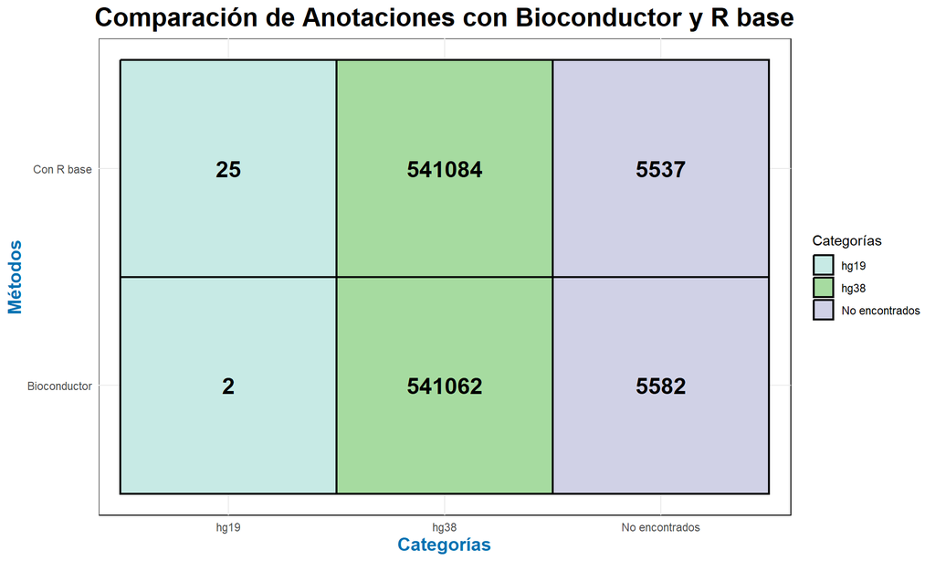

## 7 - Analysis 🔬

In the first quality control performed with only quality parameters, SNPs with no assigned sex were obtained, which was inconvenient. In the second QC, improvement was made by adding sex assignment with PLINK using the –check-sex option, resulting in only one SNP not being assigned a sex from the 13,722 that existed initially. Additionally, the quality control parameters were improved by adding the options –maf 0.01 and –hwe 1e-6, which provided better filtering, resulting in 546,522 SNPs in the first QC and 541,024 SNPs in the second QC.

In the genome annotation section, a total of 541,064 annotated results were obtained with Bioconductor, of which only 2 belonged to hg19. Performing the annotation using only R resulted in 541,109 annotated entries, of which 25 belonged to hg19. As a result, more annotations were obtained with base R compared to Bioconductor, likely due to the possibility that the Bioconductor database is not up-to-date. Therefore, using the NCBI datasets provided better results.

## 8 - Conclusions 💡

This work presents a pipeline for the preparation prior to genomic variant imputation, using standard tools such as PLINK, Bioconductor, and base R. Additionally, different methods were compared, and the ones that provided better results will be used to continue with the subsequent analyses.

## 9 - Challenges 🚀

- Continue with further processing such as genomic imputation, and analysis with PrediXcan and MetaXcan.
- Optimizing resource usage and scripts.
- Automating the process and performing deeper analyses with the final results.
- Presenting the obtained results at the end of the entire process in an appealing manner following the scientific method.
- Generate actionable genetic markers that can improve genetic risk prediction

## 10 - References 📚

- Purcell S, Neale B, Todd-Brown K, et al. (2007). PLINK: A Tool Set for Whole-Genome Association and Population-Based Linkage Analyses. *American Journal of Human Genetics, 81*(3), 559-575. Disponible en: [PLINK: Whole-genome association analysis toolset](https://www.cog-genomics.org/plink/)
- UCSC Genome Browser. (n.d.). LiftOver Tool. Disponible en: [UCSC LiftOver](http://genome.ucsc.edu/cgi-bin/hgLiftOver)
- Bioconductor AnnotationHub. (n.d.). AnnotationHub: A Bioconductor Package for Annotation Data. Disponible en: [Bioconductor AnnotationHub](https://bioconductor.org/packages/release/bioc/html/AnnotationHub.html)
- UCSC Genome Browser. (n.d.). Genoma de referencia: `hg19` y `hg38`. Disponible en: [UCSC Genome Browser - GoldenPath](https://hgdownload.cse.ucsc.edu/goldenPath/)
- UCSC Genome Browser. (n.d.). Cadena de conversión `hg38ToHg19.over.chain`. Disponible en: [UCSC Genome Browser - LiftOver Chain Files](https://hgdownload.cse.ucsc.edu/goldenpath/hg38/liftOver/)
- Anaconda. (n.d.). Conda: Herramienta para la gestión de ambientes y paquetes. Disponible en: [Anaconda](https://www.anaconda.com/)
- R Project. (n.d.). R: Un lenguaje y entorno para la computación estadística. Disponible en: [R Project](https://www.r-project.org/)
- Bioconductor. (n.d.). Bioconductor: Herramientas para análisis de datos genómicos. Disponible en: [Bioconductor](https://www.bioconductor.org/)
- Purcell S, Neale B, Todd-Brown K, et al. (2007). PLINK: A Tool Set for Whole-Genome Association and Population-Based Linkage Analyses. *American Journal of Human Genetics, 81*(3), 559-575. Disponible en: [PLINK: Whole-genome association analysis toolset](https://www.cog-genomics.org/plink/)
- UCSC Genome Browser. (n.d.). LiftOver Tool. Disponible en: [UCSC LiftOver](http://genome.ucsc.edu/cgi-bin/hgLiftOver)
- Bioconductor AnnotationHub. (n.d.). AnnotationHub: A Bioconductor Package for Annotation Data. Disponible en: [Bioconductor AnnotationHub](https://bioconductor.org/packages/release/bioc/html/AnnotationHub.html)
- UCSC Genome Browser. (n.d.). Genoma de referencia: `hg19` y `hg38`. Disponible en: [UCSC Genome Browser - GoldenPath](https://hgdownload.cse.ucsc.edu/goldenPath/)
- UCSC Genome Browser. (n.d.). Cadena de conversión `hg38ToHg19.over.chain`. Disponible en: [UCSC Genome Browser - LiftOver Chain Files](https://hgdownload.cse.ucsc.edu/goldenpath/hg38/liftOver/)